# Tutorial #4: Minimum Legal Drinking Age

This problem is based on data from [Carpenter & Dobkin (2009; AEJ Applied)](http://masteringmetrics.com/wp-content/uploads/2015/01/Carpenter-and-Dobkin-2009.pdf), who study the causal effect of alcohol consumption on mortality in US youths. In 1984, the US Federal Government introduced legislation that compelled states to introduce a minimum legal drinking age (MLDA) of 21. Before then, different states had different minimum ages at which it was legal to purchase alcohol: some had an MLDA of 18, others 19, and others 20. Carter & Dobkin (2009) do *not* rely upon variation in states’ MLDAs before 1984. (If you’re interested to know why, see the introduction of their paper.) Instead they take a regression discontinuity approach. Since 1984, a US resident’s *birthday* has created a sharp change in ease of access to alcohol. The day before your 21st birthday, you cannot buy alcohol legally; on the day itself and forever after you can. If we view the treatment as *being able to buy alcohol legally*, this is a *sharp* RD design. The outcome of interest is all-cause mortality. If legal access to alcohol causes an increase in mortality, we should see a “jump” in mortality rates just after people turn 21. For more background, see the paper.

1. Use a linear RD model to estimate the causal effect of legal access to alcohol on death rates. Plot your results and carry out appropriate present appropriate statistical inference. Discuss your findings.
2. Repeat 1 using a *quadratic* rather than linear specification. Compare and contrast your findings.
3. RD analysis is fundamentally *local* in nature: the mortality rates of individuals far from the cutoff should not inform us about the causal effect for 21 year olds. Check the sensitivity of your results from parts 1 and 2 by restricting your sample to ages between 20 and 22, inclusive. Discuss your findings.

## Solutions

```r
# Load data
library(tidyverse)
library(haven)
library(modelsummary)
library(gt)
mlda <- read_dta('https://ditraglia.com/data/mlda.dta')
```

### Table of Regression Results

```r
# Center age around the cutoff and create treatment indicator
mlda <- mlda |>
  mutate(age = agecell - 21,
         over21 = if_else(agecell >= 21, 1, 0))

# Linear RD model
linear_model <- all ~ age * over21
linear_RD <-  lm(linear_model, mlda)

# Quadratic RD Model
quadratic_model <- all ~ (age + I(age^2)) * over21
quadratic_RD <-  lm(quadratic_model, mlda)

# Sensitivity Analysis: what changes if we restrict to ages 20-22?
mlda_subset <- mlda |>
  filter(agecell >= 20 & agecell <= 22)

linear_RD_local <-  lm(linear_model, mlda_subset)
quadratic_RD_local <- lm(quadratic_model, mlda_subset)

results <- list(linear_RD, quadratic_RD, linear_RD_local, quadratic_RD_local)
RD_table <- modelsummary(results,
                         fmt = 2,
                         output = 'gt',
                         stars = TRUE,
                         gof_omit = 'Log.Lik|R2|R2 Adj.|AIC|BIC|F|RMSE',
                         title = 'Sharp RD Results - MLDA Example')
RD_table |>
  tab_spanner(label = 'Ages 19-23', columns = 2:3) |>
  tab_spanner(label = 'Ages 20-22', columns = 4:5)
```

Sharp RD Results - MLDA Example

|  | Ages 19-23 (1) | Ages 19-23 (2) | Ages 20-22 (3) | Ages 20-22 (4) |
| --- | --- | --- | --- | --- |
| (Intercept) | 93.62*** | 93.07*** | 92.52*** | 94.34*** |
|  | (0.93) | (1.40) | (1.37) | (2.05) |
| age | 0.83 | -0.83 | -1.61 | 9.40 |
|  | (0.82) | (3.29) | (2.41) | (9.62) |
| over21 | 7.66*** | 9.55*** | 9.75*** | 9.61** |
|  | (1.32) | (1.99) | (1.94) | (2.89) |
| age × over21 | -3.60** | -6.02 | -3.29 | -24.45+ |
|  | (1.16) | (4.65) | (3.40) | (13.60) |
| I(age^2) |  | -0.84 |  | 11.16 |
|  |  | (1.62) |  | (9.45) |
| I(age^2) × over21 |  | 2.90 |  | -0.87 |
|  |  | (2.28) |  | (13.37) |
| Num.Obs. | 48 | 48 | 24 | 24 |

+ p < 0.1, * p < 0.05, ** p < 0.01, *** p < 0.001

### Base R Versions of Plots

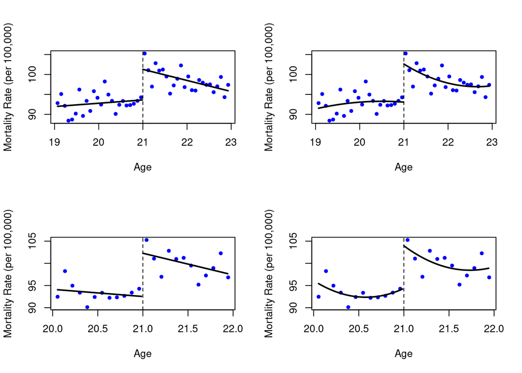

```r
# Function for making an RD plot
make_RD_plot <- function(reg, dat, inc = 0.01) {
  plot(all ~ agecell, dat, xlab = 'Age',
       ylab = 'Mortality Rate (per 100,000)',
       pch = 20, col = 'blue')
  abline(v = 21, lty = 2)
  x_min <- min(dat$agecell)
  x_max <- max(dat$agecell)
  x_before <- seq(x_min, 21 - inc, inc)
  x_after <- seq(21, x_max, inc)
  y_before <- predict(reg, data.frame(age = x_before - 21,
                                         over21 = 1 * (x_before >= 21)))
  y_after <- predict(reg, data.frame(age = x_after - 21,
                                        over21 = 1 * (x_after >= 21)))
  points(x_before, y_before, type = 'l', lwd = 2)
  points(x_after, y_after, type = 'l', lwd = 2)
}


par(mfrow = c(2, 2))
make_RD_plot(linear_RD, mlda)
make_RD_plot(quadratic_RD, mlda)
make_RD_plot(linear_RD_local, mlda_subset)
make_RD_plot(quadratic_RD_local, mlda_subset)
```

```r
par(mfrow = c(1, 1))
```

### `ggplot2` Versions of the Plots

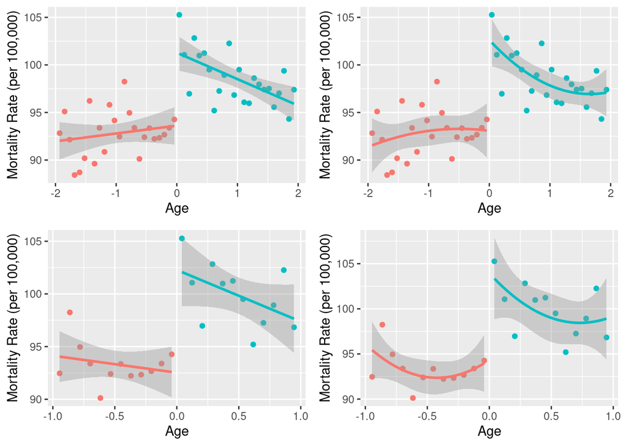

```r
library(gridExtra)

linear_plot <- ggplot(mlda, aes(x = age, y = all, color = factor(over21))) +
  geom_point() +
  geom_smooth(method = 'lm', formula = y ~ x) +
  xlab('Age') +
  ylab('Mortality Rate (per 100,000)') +
  theme(legend.position = 'none') # Get rid of the legend!

quadratic_plot <- ggplot(mlda, aes(x = age, y = all, color = factor(over21))) +
  geom_point() +
  geom_smooth(method = 'lm', formula = y ~ x + I(x^2)) +
  xlab('Age') +
  ylab('Mortality Rate (per 100,000)') +
  theme(legend.position = 'none') # Get rid of the legend!

linear_plot_local <- ggplot(mlda_subset, aes(x = age, y = all,
                                             color = factor(over21))) +
  geom_point() +
  geom_smooth(method = 'lm', formula = y ~ x) +
  xlab('Age') +
  ylab('Mortality Rate (per 100,000)') +
  theme(legend.position = 'none') # Get rid of the legend!

quadratic_plot_local <- ggplot(mlda_subset, aes(x = age, y = all,
                                                color = factor(over21))) +
  geom_point() +
  geom_smooth(method = 'lm', formula = y ~ x + I(x^2)) +
  xlab('Age') +
  ylab('Mortality Rate (per 100,000)') +
  theme(legend.position = 'none') # Get rid of the legend!

grid.arrange(linear_plot, quadratic_plot,
             linear_plot_local, quadratic_plot_local, ncol = 2)
```